# Exploratory Data Analysis

# 1 Introduction to `ggplot2`

```r
library(tidyverse)
library(datasets)
library(patchwork)
data("mtcars")
```

## 1.1 The grammar of graphics

- Data: the dataset to use
- Geometry: the type of graphic to be plotted.
- Aesthetics: Are what are to be seen in a plot. x axis, y axis, color, fill, shape, opacity, width and line type.
- Statistics: graphics where there is a need to indicate the number of bins, regression type…
- Coordinates: Cartesian or Polar coordinates. The x and y Cartesian coordinates by default will be used.
- Facets: to plot multiple graphics for different groups.
- Themes: are the preset configurations such as background color, grid, fonts…

## 1.2 Basic syntax of ggplot2

The basic syntax follows the order:

1. What is the dataset to be used?
2. What kind of graphic will be plotted?
3. What goes on the X axis and Y axis?
4. What is the graphic title?

```r
ggplot(data = df) +     # data set to use
    geom_point(         # type of grapth to plot
    mapping = aes( x = X, y = Y) ) +        # Aesthetics
    ggtitle("Title")    # Title
```

## 1.3 Plot types

### 1.3.1 Histograms

- `geom_histogram()`

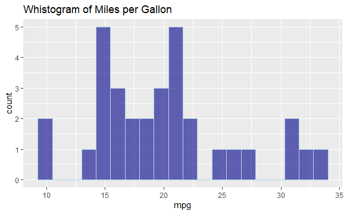

```r
ggplot(mtcars) +
    geom_histogram(
        mapping = aes( x = mpg ),
        bins = 20,
        color = "lightblue",
        fill = "darkblue",
        alpha = 0.6
    ) +
    ggtitle( "Whistogram of Miles per Gallon" )
```

### 1.3.2 Boxplot

- `geom_boxplot()`

For univariate plots it required only one axis. For multivariate the categories could be on X.

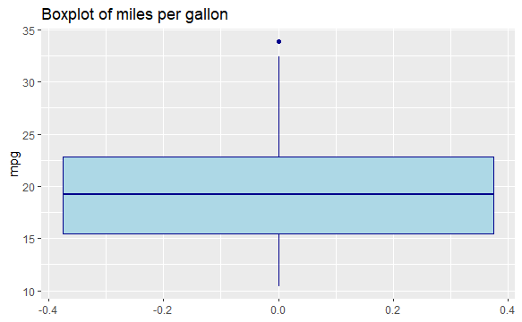

```r
ggplot( data = mtcars ) +
    geom_boxplot( aes( y = mpg ), fill = "lightblue", color = "darkblue" ) +
    ggtitle( "Boxplot of miles per gallon")
```

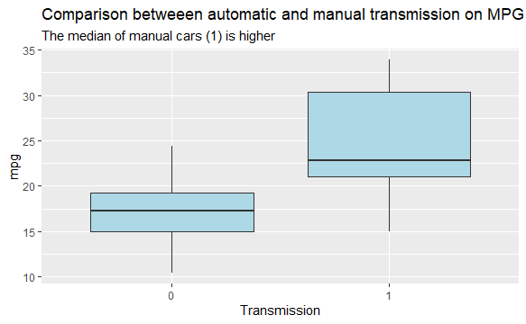

```r
ggplot( mtcars ) +
    geom_boxplot( aes( x = factor(am),
                       y = mpg ), fill = "lightblue" ) +
    labs( x = "Transmission",
          title = "Comparison betweeen automatic and manual transmission on MPG",
          subtitle = "The median of manual cars (1) is higher" )
```

### 1.3.3 Scatterplot

- `geom_point()`

Useful for see relationships between variables and correlations.

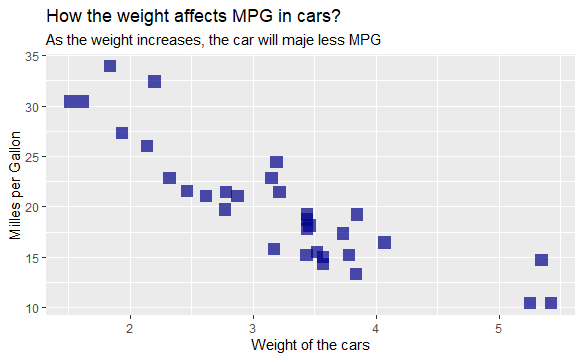

```r
ggplot( data = mtcars ) +
    geom_point( aes( x = wt, y = mpg ),
                color = "darkblue",
                size = 4,
                shape = 15, # squares
                alpha = 0.7 ) +
    labs ( x = "Weight of the cars",
           y = "Milles per Gallon",
           title = "How the weight affects MPG in cars?",
           subtitle = "As the weight increases, the car will maje less MPG")
```

### 1.3.4 Barplots

- `geom_bar()`
- `stat_summary()`: alternative to geom_bar(), given the aesthetics, function and geometry to use.
- `geom_col()`: requires x and y axes. It will return the bars with the summed y-axis by category.

Useful for categorical variables to show counts or values.

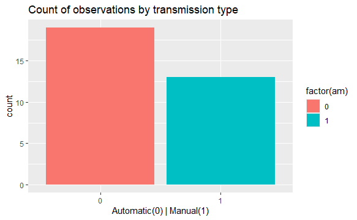

```r
ggplot( mtcars ) +
    geom_bar( aes( x = factor(am),
                   fill = factor(am) ) ) +
                 # Fill in 'aes' using the same factor means color per category
    labs( x = "Automatic(0) | Manual(1)" ) +
    ggtitle( "Count of observations by transmission type" )
```

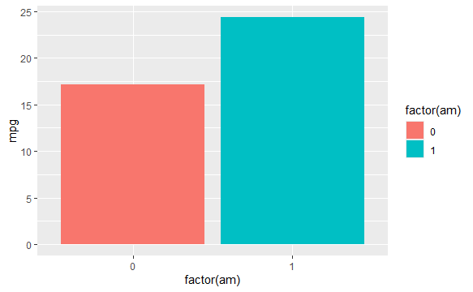

```r
ggplot( mtcars ) +
    geom_bar( aes( x = factor(am),
                   y = mpg,
                   fill = factor(am) ),
              stat = "summary", fun = "mean" ) # To use the mean on 'y' axis
```

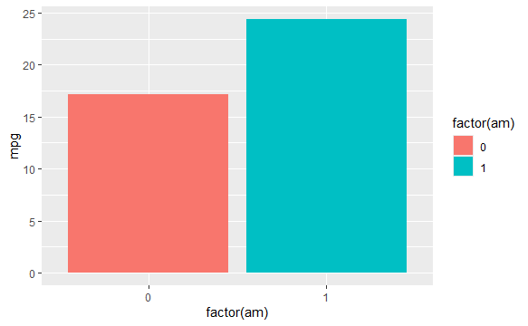

```r
ggplot( mtcars ) +
    stat_summary( aes( x = factor(am),
                       y = mpg,
                       fill = factor(am) ),
                  fun = "mean",
                  geom = "bar" )
```

```r
    # Alternative to the previous graphic
```

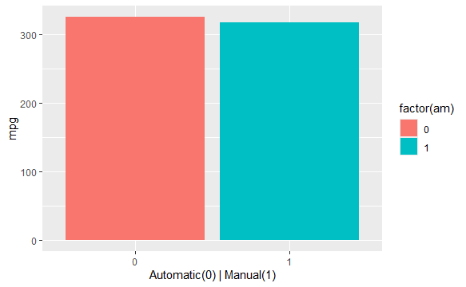

```r
ggplot( mtcars ) +
    geom_col( aes( x = factor(am),
                   y = mpg,
                   fill = factor(am) ) ) +
    labs( x = "Automatic(0) | Manual(1)" )
```

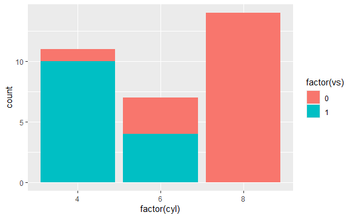

```r
ggplot( mtcars ) +
    geom_bar( aes( x = factor(cyl), fill = factor(vs) ),
              position = "stack" )
```

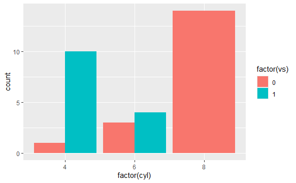

```r
ggplot( mtcars ) +
    geom_bar( aes( x = factor(cyl), fill = factor(vs) ),
              position = "dodge" )
```

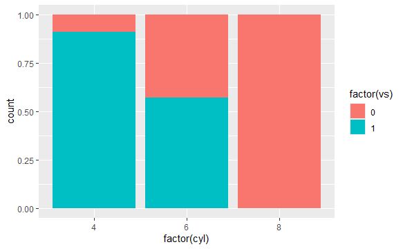

```r
ggplot( mtcars ) +
    geom_bar( aes( x = factor(cyl), fill = factor(vs) ),
              position = "fill" )
```

### 1.3.5 Line plots

- `geom_line()`

Useful to show progression over time.

```r
df.line <- data.frame(
    month = seq(1, 12, 1),
    sales = rlnorm(12),
    sales2 = rgamma(12, 1)
)
df.line[1:5,]
```

|  | month | sales | sales2 |
| --- | --- | --- | --- |
| 1 | 1 | 0.8233731 | 1.5830301 |
| 2 | 2 | 2.0841239 | 0.7653663 |
| 3 | 3 | 1.4879666 | 1.2158406 |
| 4 | 4 | 0.5036506 | 0.1412535 |
| 5 | 5 | 1.1913027 | 0.5470342 |

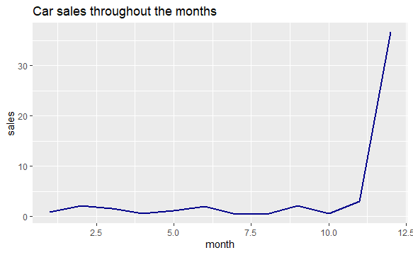

```r
ggplot( df.line ) +
    geom_line( aes( x = month,
                    y = sales,
                    group = 1),
               linewidth = 1,
               color = "darkblue" ) +
    ggtitle( "Car sales throughout the months")
```

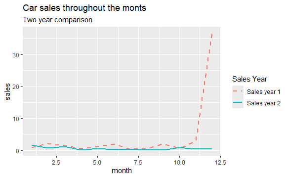

```r
ggplot( df.line ) +
    geom_line( aes( x = month,
                    y = sales,
                    group = 1,
                    color = "Sales year 1"), # the label for this line
               linewidth = 1,
               linetype = 2) +
    geom_line( aes( x = month,
                    y = sales2,
                    group = 1,
                    color = "Sales year 2"),
               linewidth = 1,
               linetype = 1) +
    ggtitle( "Car sales throughout the monts" ) +
    labs( subtitle = "Two year comparison",
          color = "Sales Year") # The title for the legend
```

### 1.3.6 Smooth geometry

- `geom_smooth()`
- `method=` by default polynomial function (`loess`). There are also linear regression (`lm`) generalized additive models (`gam`), robust linear models (`rlm`) and generalized linear models (`glm`).

It calculates a line that helps to see a trend in the points, using linear regression, polynomial regression or a general linear model.

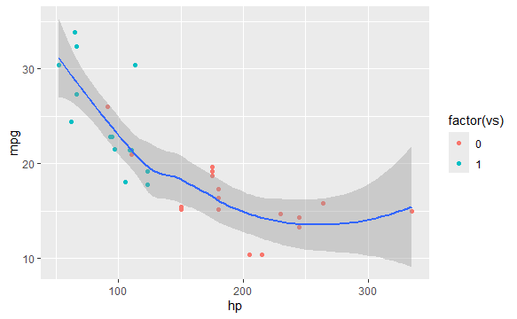

```r
ggplot( mtcars ) +
  geom_point( aes( x = hp,
                   y = mpg,
                   color = factor(vs) ) ) +
  geom_smooth( aes( x = hp,
                    y = mpg ),
               method = 'loess' )
```

We can add `aes()` to `ggplot()` to be more efficient.

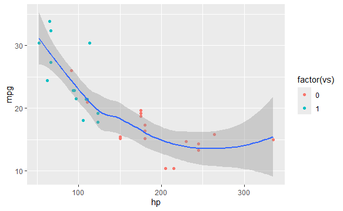

```r
ggplot( mtcars, aes( x = hp, y = mpg ) ) +
  geom_point( aes( color = factor(vs) ) ) +
  geom_smooth( method = 'loess' )
```

### 1.3.7 Themes

- `theme_bw(), theme_classic(), theme_light(), theme_dark(), theme_gray(), theme_linedraw(), theme_minimal(), and theme_void()`

Can be added to the visualization plot to change the preset visual configuration. Let’s see how looks the last visualization:

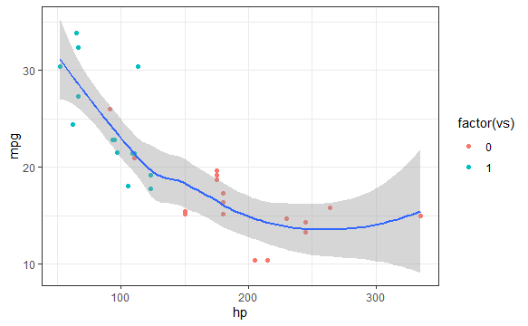

```r
ggplot( mtcars, aes( x = hp, y = mpg ) ) +
  geom_point( aes( color = factor(vs) ) ) +
  geom_smooth( method = 'loess' ) +
  theme_bw()
```

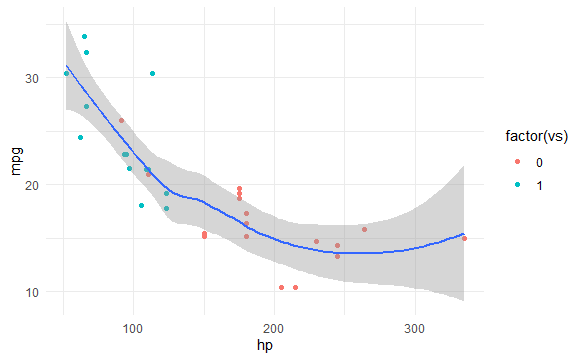

```r
ggplot( mtcars, aes( x = hp, y = mpg ) ) +
  geom_point( aes( color = factor(vs) ) ) +
  geom_smooth( method = 'loess' ) +
  theme_minimal()
```

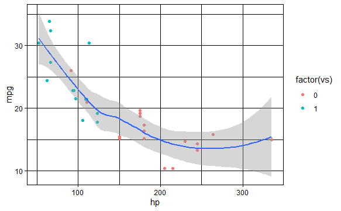

```r
ggplot( mtcars, aes( x = hp, y = mpg ) ) +
  geom_point( aes( color = factor(vs) ) ) +
  geom_smooth( method = 'loess' ) +
  theme_linedraw()
```

## 1.4 Useful links

Cheatsheet:

https://github.com/rstudio/cheatsheets/blob/4ee6c2f03a32478560f927834af25c13c899a0a2/data-visualization.pdf

Adding labels to a graph with `geom_text()`:

https://r-graphics.org/recipe-bar-graph-labels

# 2 Enchanced Visualizations `ggplot2`

```r
library(tidyverse)
library(lubridate)
library(datasets)
library(patchwork)
library(plotly)
#data("diamonds")
```

## 2.1 Facet grids

Facet grids to generate multiple graphics on a matrix.

- `facet_grid()`: to divide the visualization
- `facet_wrap()`: forces the subplots into a rectangular matrix
- `vars()`: it is needed to pass the variables which will divide the `facet_grid()` or `facet_wrap()`.

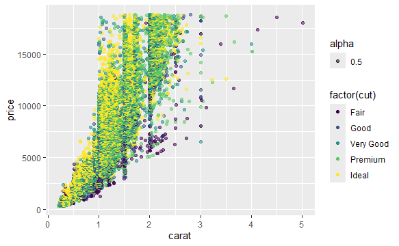

```r
df.diam <- diamonds

ggplot( df.diam ) +
  geom_point( aes( x = carat, y = price, color = factor(cut) , alpha = 0.5) )
```

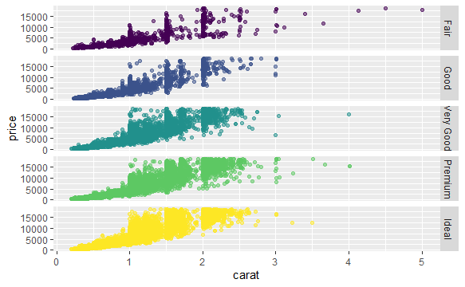

```r
ggplot( df.diam ) +
  geom_point( aes( x = carat, y = price,
                   color = factor(cut),
                   alpha = 0.5 ) ) +
  facet_grid(rows = vars(cut) ) +
  theme(legend.position = "none")
```

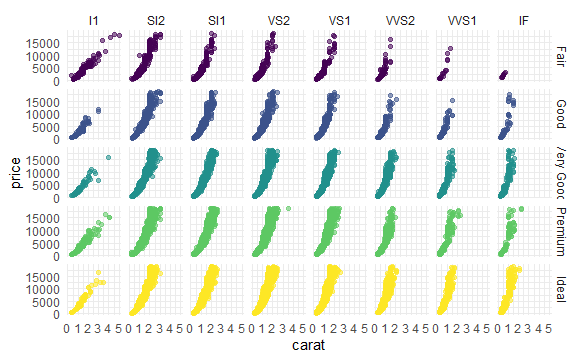

```r
ggplot( df.diam ) +
  geom_point( aes( x = carat, y = price,
                   color = cut, alpha = 0.6 ) ) +
  facet_grid( rows = vars(cut), cols = vars(clarity) ) +
  theme_minimal() +
  theme( legend.position = "none")
```

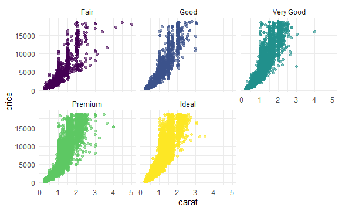

```r
g <- ggplot( df.diam ) +
  geom_point( aes( x = carat, y = price,
                   color = factor(cut),
                   alpha = 0.5 ) ) +
  facet_grid(rows = vars(cut) ) +
  theme_minimal() +
  theme( legend.position = "none" )
g + facet_wrap( vars(cut) )
```

## 2.2 Map plots

This section will be a slightly view to the capabilities of ggplot2 with spatial data analysis.

- geom_map()

The first thing to do is to load the map to an object. Then we have to map the locations of state capitals.

```r
# Load the map

us <- map_data("state")
url <- "https://raw.githubusercontent.com/PacktPublishing/Data-Wrangling-with-R/main/Part3/Chapter11/USA_states.csv"
states <- read_csv(url)
```

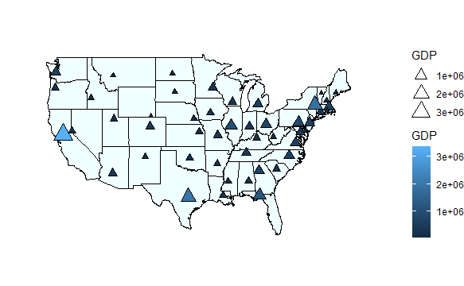

```r
# 'state' column to lowercase
states <- states %>% mutate( state = str_to_lower(state) )

# Map locations
us_map <- ggplot( states ) +
  geom_map( aes( longitude, latitude,
                 map_id = state),
            map = us, color = "black", fill = "azure" ) +
  xlim(-130, -60) +
  ylim(20,55) +
  theme_void()
us_map +
  geom_point( aes( x = longitude,
                   y = latitude,
                   size = GDP,
                   fill = GDP),
              shape = 24 )
```

The `xlim()` and `ylim()` center the map to the states, there are other two points out of the map.

## 2.3 Time series plots

Line plots may be the best type of graph to visualize a time series which is a sequence of days, months or other kind of time frame.

We will add to the plot `scale_x_date()` to create x-tics with the dates. Can be limited to make a ‘close up’ in a month with `limit=` argument, for example. With the argument `date_breaks()` it can be specified when we want a tick, the `date_labels=` argument to specified the format of date to print.

```r
df.time <- data.frame(
  date = seq(ymd('2022-01-01'), ymd('2022-06-30'), by = 'days'),
  measure = as.integer(runif(181, min = 600, max = 1000) +
    sort( rexp( 181, 0.001 ) ) )
)
head(df.time)
```

|  | date | measure |
| --- | --- | --- |
| 1 | 2022-01-01 | 830 |
| 2 | 2022-01-02 | 817 |
| 3 | 2022-01-03 | 741 |
| 4 | 2022-01-04 | 839 |
| 5 | 2022-01-05 | 672 |
| 6 | 2022-01-06 | 757 |

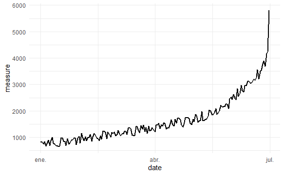

```r
basic.plot <- ggplot( df.time ) +
  geom_line( aes( x = date, y = measure ), size = 0.8 ) +
  theme_minimal()
basic.plot
```

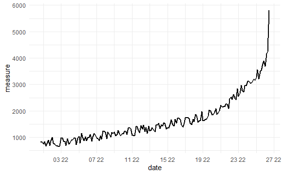

```r
basic.plot +
  scale_x_date(date_breaks = "4 weeks", date_labels = "%W %y")
```

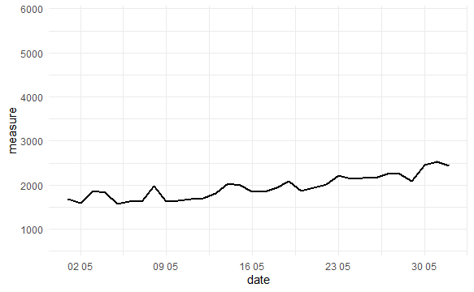

```r
basic.plot +
  scale_x_date(date_breaks = "1 weeks", date_labels = "%d %m",
               limit=as.Date( c("2022-05-01", "2022-06-01") ) )
```

## 2.4 3D Plots